# DATA624 Project-1

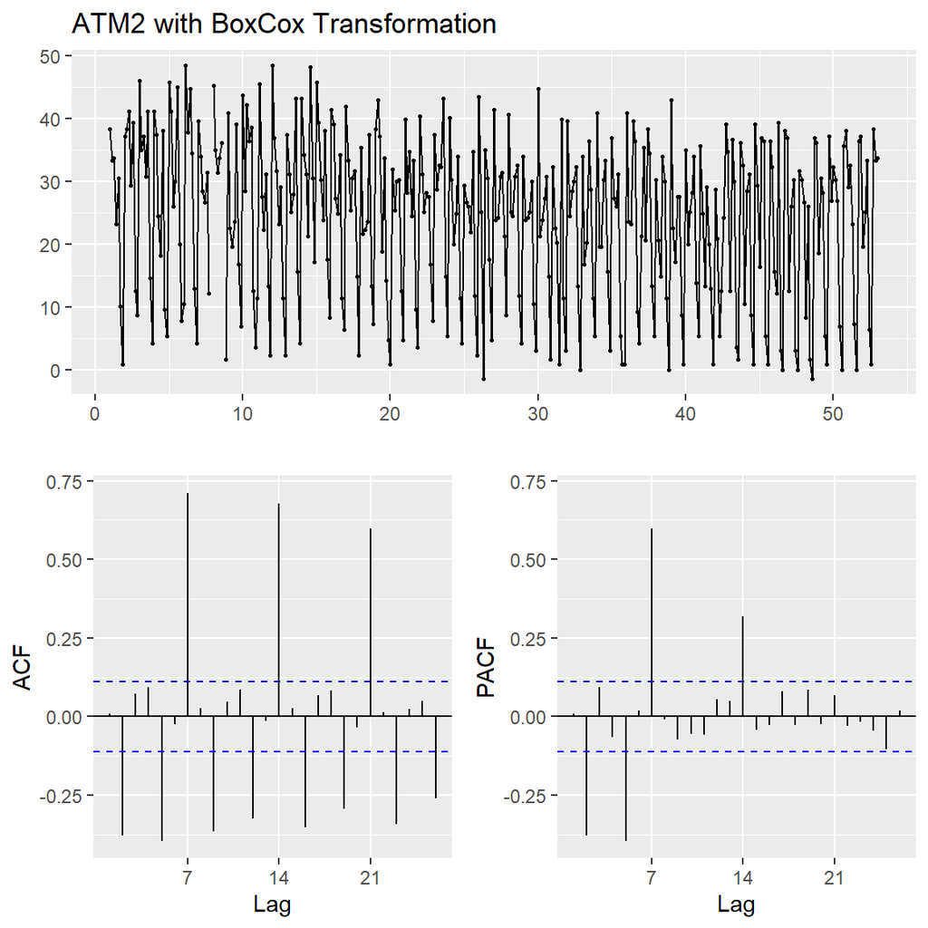

```r
atm2_bc <- BoxCox(atm2, lambda = BoxCox.lambda(atm2))
ggtsdisplay(atm2_bc, main="ATM2 with BoxCox Transformation")
```

After applying Box-Cox transformation, we still see the weekly seasonality in the timeseries. Differencing is needed.

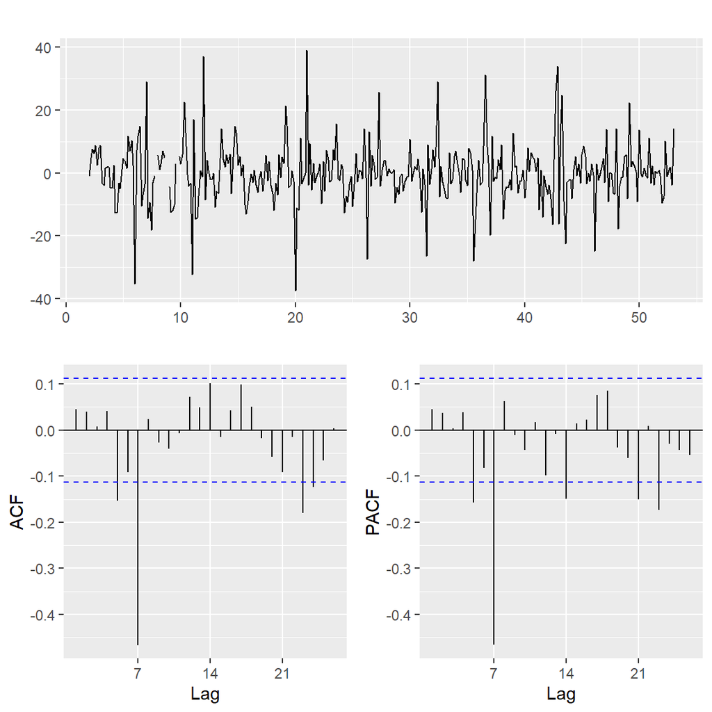

```r
ggtsdisplay(diff(atm2_bc, 7), points=FALSE)
```

```r
atm2_bc %>% diff(.,7) %>% ur.kpss() %>% summary()
```

```
##
## #######################
## # KPSS Unit Root Test #
## #######################
##
## Test is of type: mu with 5 lags.
##
## Value of test-statistic is: 0.0161
##
## Critical value for a significance level of:
##                 10pct  5pct 2.5pct  1pct
## critical values 0.347 0.463  0.574 0.739
```

The timeseries now appears to be stationary. One seasonal differencing was applied so D=1, while the non-seasonal part suggests d=0. The seasonal lags at ACF sudden drops while the ones in PACF gradually decrease, suggest AR(0) and MA(1), so P=0, Q=1. The non-differenced ACF and PACF plots have spikes at lag2 and lag5, suggest p=2 and q=2. I will try ARIMA(2,0,2)(0,1,1)[7].

```r
atm2_arima <- Arima(atm2, order=c(2,0,2), seasonal=c(0,1,1), lambda = BoxCox.lambda(atm2))
summary(atm2_arima)
```

```
## Series: atm2
## ARIMA(2,0,2)(0,1,1)[7]
## Box Cox transformation: lambda= 0.7164431
##
## Coefficients:
##           ar1      ar2     ma1     ma2     sma1
##       -0.4188  -0.9019  0.4587  0.7886  -0.7187
## s.e.   0.0587   0.0471  0.0884  0.0619   0.0414
##
## sigma^2 = 62.19:  log likelihood = -1240.08
## AIC=2492.16   AICc=2492.4   BIC=2515.45
##
## Training set error measures:
##                     ME     RMSE      MAE  MPE MAPE      MASE        ACF1
## Training set 0.2631418 24.22403 16.90092 -Inf  Inf 0.8250038 -0.01464052
```

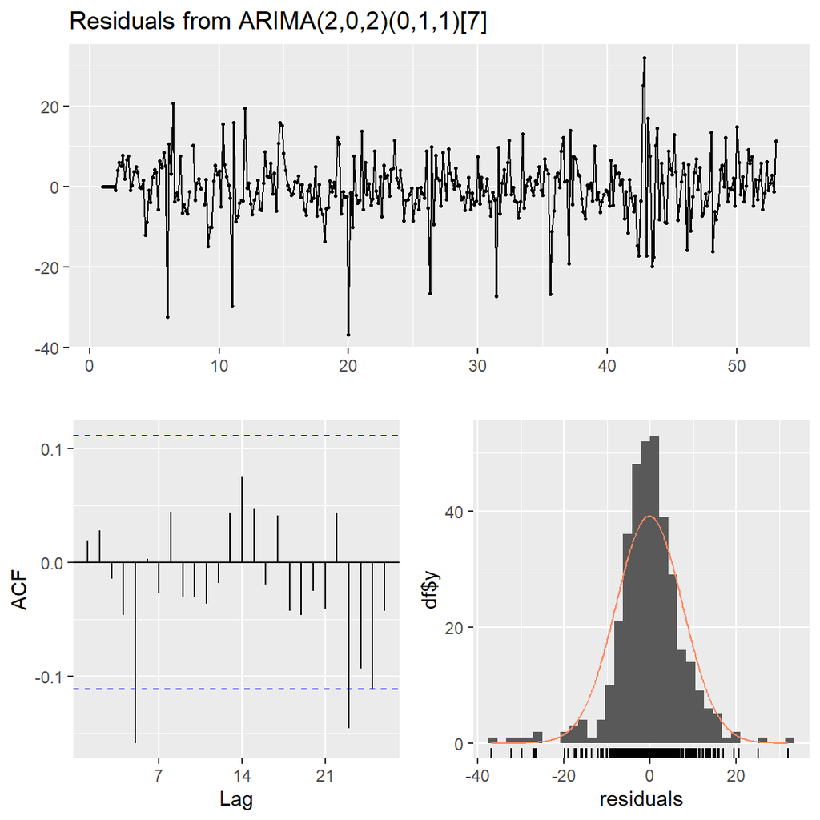

```
##
##  Ljung-Box test
##
## data:  Residuals from ARIMA(2,0,2)(0,1,1)[7]
## Q* = 9.8051, df = 9, p-value = 0.3665
##
## Model df: 5.   Total lags used: 14
```

```r
checkresiduals(atm2_arima)
```

Now, let’s use auto.arima to find out which is the best Arima model:

```r
atm2_auto <- auto.arima(atm2, approximation = FALSE, lambda=BoxCox.lambda(atm2))
summary(atm2_auto)
```

```
## Series: atm2
## ARIMA(2,0,2)(0,1,1)[7]
## Box Cox transformation: lambda= 0.7164431
##
## Coefficients:
##           ar1      ar2     ma1     ma2     sma1
##       -0.4188  -0.9019  0.4587  0.7886  -0.7187
## s.e.   0.0587   0.0471  0.0884  0.0619   0.0414
##
## sigma^2 = 62.19:  log likelihood = -1240.08
## AIC=2492.16   AICc=2492.4   BIC=2515.45
##
## Training set error measures:
##                     ME     RMSE      MAE  MPE MAPE      MASE        ACF1
## Training set 0.2631418 24.22403 16.90092 -Inf  Inf 0.8250038 -0.01464052
```

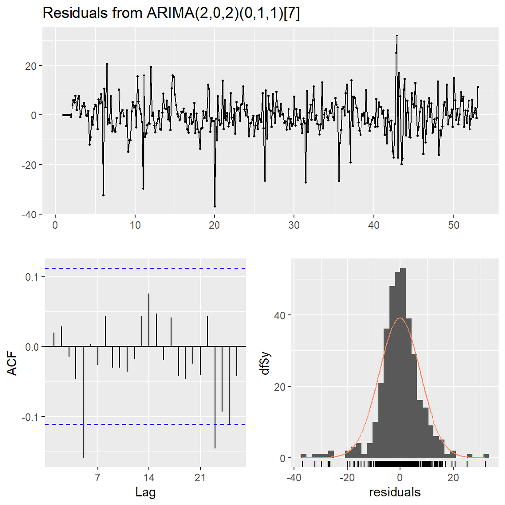

```
##
##  Ljung-Box test
##
## data:  Residuals from ARIMA(2,0,2)(0,1,1)[7]
## Q* = 9.8051, df = 9, p-value = 0.3665
##
## Model df: 5.   Total lags used: 14
```

```r
checkresiduals(atm2_auto)
```

```r
atm2_model <- Arima(atm2, order=c(2,0,2), seasonal=c(0,1,1), lambda = BoxCox.lambda(atm2))
```